# AMS 617 cat

## R Markdown

1. Generate Appropriate Graphs to Present the Data

```r
# Load necessary libraries
library(ggplot2)
library(dplyr)
library(readr)
library(corrplot)
library(tinytex)
```

```r
# Load dataset
df <- read_csv("C:\\Users\\franc\\rdatascience\\projects\\Housing.csv", show_col_types = FALSE)

# Convert categorical variables to factors
categorical_columns <- c("mainroad", "guestroom", "basement",
                         "hotwaterheating", "airconditioning", "prefarea", "furnishingstatus")

df[categorical_columns] <- lapply(df[categorical_columns], as.factor)

# View the first few rows
head(df)
```

| price | area | bedrooms | bathrooms | stories | mainroad | guestroom | basement | hotwaterheating | airconditioning | parking | prefarea | furnishingstatus |
| --- | --- | --- | --- | --- | --- | --- | --- | --- | --- | --- | --- | --- |
| 13.300 | 7.42 | 4 | 2 | 3 | yes | no | no | no | yes | 2 | yes | furnished |
| 12.250 | 8.96 | 4 | 4 | 4 | yes | no | no | no | yes | 3 | no | furnished |
| 12.250 | 9.96 | 3 | 2 | 2 | yes | no | yes | no | no | 2 | yes | semi-furnished |
| 12.215 | 7.50 | 4 | 2 | 2 | yes | no | yes | no | yes | 3 | yes | furnished |
| 11.410 | 7.42 | 4 | 1 | 2 | yes | yes | yes | no | yes | 2 | no | furnished |
| 10.850 | 7.50 | 3 | 3 | 1 | yes | no | yes | no | yes | 2 | yes | semi-furnished |

Explanation show_col_types = FALSE → Suppresses the message. as.factor() → Converts categorical (chr) columns to factor. lapply(df[categorical_columns], as.factor) → Converts all specified categorical columns.

Histogram of House Prices

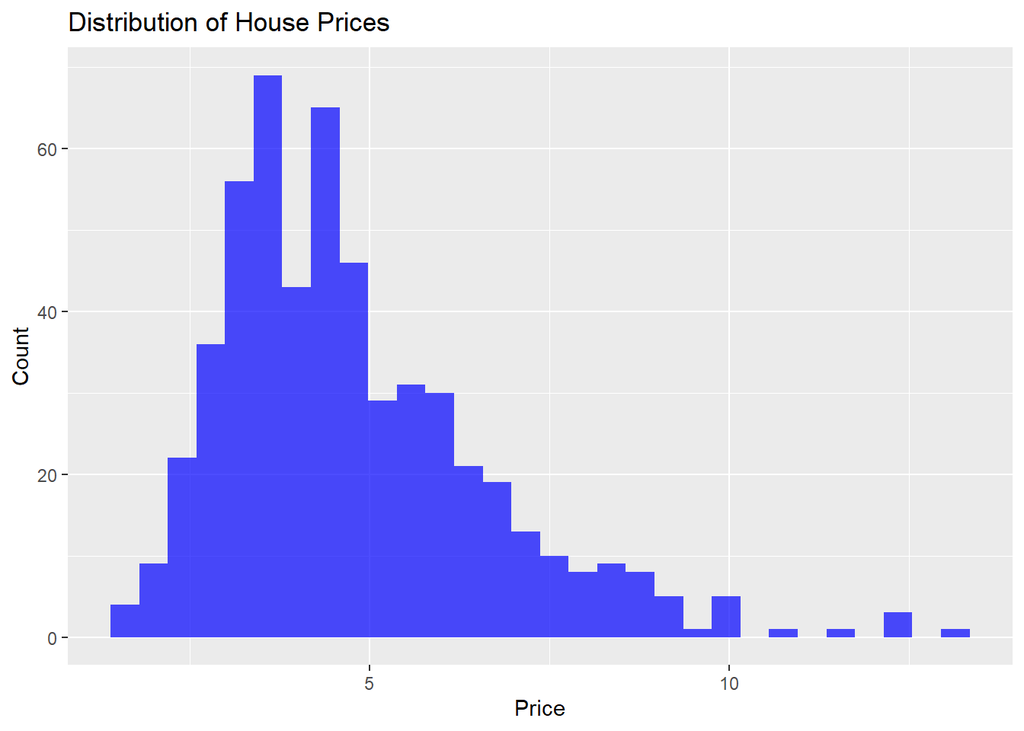

```r
ggplot(df, aes(x = price)) +
  geom_histogram(fill = "blue", bins = 30, alpha = 0.7) +
  labs(title = "Distribution of House Prices", x = "Price", y = "Count")
```

Scatter Plot: Price vs. Area

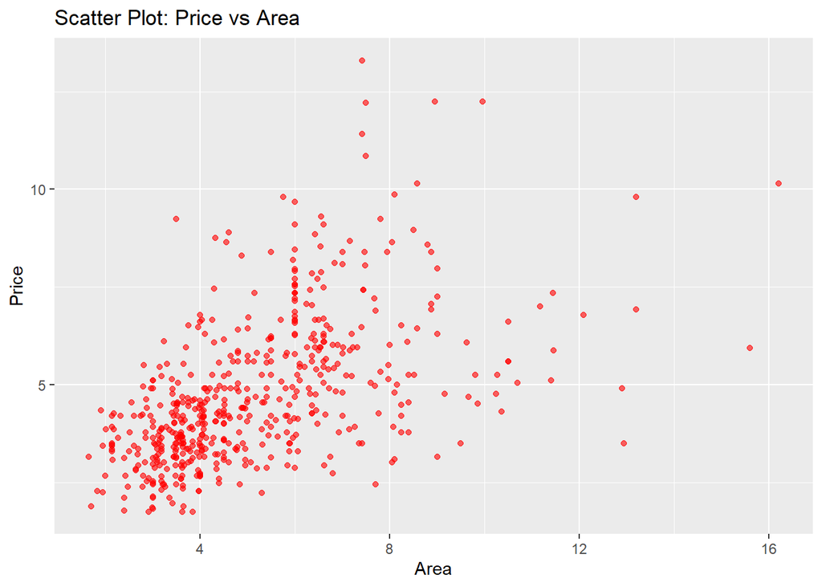

```r
ggplot(df, aes(x = area, y = price)) +
  geom_point(color = "red", alpha = 0.6) +
  labs(title = "Scatter Plot: Price vs Area", x = "Area", y = "Price")
```

Correlation Heatmap

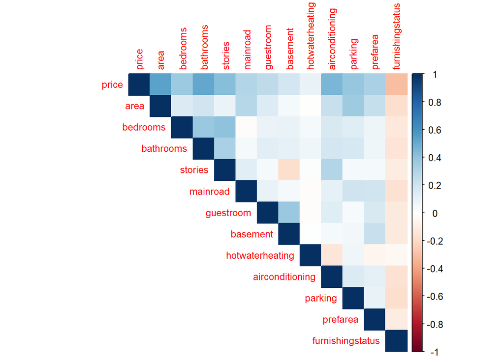

```r
# Convert categorical variables to numeric
df_numeric <- df %>%
  mutate(across(where(is.character), as.factor)) %>%
  mutate(across(where(is.factor), as.numeric))

# Compute correlation matrix
corr_matrix <- cor(df_numeric)

# Heatmap
corrplot(corr_matrix, method = "color", type = "upper", tl.cex = 0.8)
```

mutate(across(where(is.factor), as.numeric)) → Converts factors to numeric for correlation.

2. Perform Descriptive Analysis of the Dataset

```r
# Summary statistics
summary(df)
```

```
##      price             area           bedrooms       bathrooms
##  Min.   : 1.750   Min.   : 1.650   Min.   :1.000   Min.   :1.000
##  1st Qu.: 3.430   1st Qu.: 3.600   1st Qu.:2.000   1st Qu.:1.000
##  Median : 4.340   Median : 4.600   Median :3.000   Median :1.000
##  Mean   : 4.767   Mean   : 5.151   Mean   :2.965   Mean   :1.286
##  3rd Qu.: 5.740   3rd Qu.: 6.360   3rd Qu.:3.000   3rd Qu.:2.000
##  Max.   :13.300   Max.   :16.200   Max.   :6.000   Max.   :4.000
##     stories      mainroad  guestroom basement  hotwaterheating airconditioning
##  Min.   :1.000   no : 77   no :448   no :354   no :520         no :373
##  1st Qu.:1.000   yes:468   yes: 97   yes:191   yes: 25         yes:172
##  Median :2.000
##  Mean   :1.806
##  3rd Qu.:2.000
##  Max.   :4.000
##     parking       prefarea        furnishingstatus
##  Min.   :0.0000   no :417   furnished     :140
##  1st Qu.:0.0000   yes:128   semi-furnished:227
##  Median :0.0000             unfurnished   :178
##  Mean   :0.6936
##  3rd Qu.:1.0000
##  Max.   :3.0000
```

3. Formulate Five Objectives, Perform Tests of Hypothesis, and Discuss Results

If p-value ≤ 0.05, reject HO (significant effect).

If p-value > 0.05, fail to reject HO (no significant effect).

Objective 1: Does Area Affect Price?

Hypothesis:

HO: Area has no effect on price.

HA: Area has an effect on price.

```r
# Test: Pearson Correlation
cor_test <- cor.test(df$area, df$price)
cor_test
```

```
##
##  Pearson's product-moment correlation
##
## data:  df$area and df$price
## t = 14.795, df = 543, p-value < 2.2e-16
## alternative hypothesis: true correlation is not equal to 0
## 95 percent confidence interval:
##  0.4733158 0.5932784
## sample estimates:
##       cor
## 0.5359973
```

conclusion: Area has an effect on price

Objective 2: Do Houses Near the Main Road Have Higher Prices?

Hypothesis:

HO: No price difference based on proximity to the main road.

HA: Houses near the main road have different prices.

```r
# Test: t-test
t.test(price ~ mainroad, data = df)
```

```
##
##  Welch Two Sample t-test
##
## data:  price by mainroad
## t = -11.853, df = 210.68, p-value < 2.2e-16
## alternative hypothesis: true difference in means between group no and group yes is not equal to 0
## 95 percent confidence interval:
##  -1.857781 -1.327964
## sample estimates:
##  mean in group no mean in group yes
##          3.398905          4.991777
```

conclusion: Main Road has an effect on price.

p-value ≤ 0.05,hence reject HO

Objective 3: Does the Number of Bedrooms Impact Price?

Hypothesis:

HO:Number of bedrooms does not affect price.

HA:Number of bedrooms affects price.

```r
# Test: Linear Regression
model_bedrooms <- lm(price ~ bedrooms, data = df)
summary(model_bedrooms)
```

```
##
## Call:
## lm(formula = price ~ bedrooms, data = df)
##
## Residuals:
##     Min      1Q  Median      3Q     Max
## -4.6967 -1.2103 -0.2653  0.9409  7.5721
##
## Coefficients:
##             Estimate Std. Error t value Pr(>|t|)
## (Intercept)   2.0127     0.3092   6.510 1.71e-10 ***
## bedrooms      0.9288     0.1012   9.179  < 2e-16 ***
## ---
## Signif. codes:  0 '***' 0.001 '**' 0.01 '*' 0.05 '.' 0.1 ' ' 1
##
## Residual standard error: 1.742 on 543 degrees of freedom
## Multiple R-squared:  0.1343, Adjusted R-squared:  0.1327
## F-statistic: 84.25 on 1 and 543 DF,  p-value: < 2.2e-16
```

conclusion: Number of Bedrooms has an effect on price since,

p-value ≤ 0.05,hence reject HO (significant effect).

Objective 4: Is There a Significant Price Difference Between Furnished and Unfurnished Houses?

HO:No significant difference in price based on furnishing.

HA:There is a significant difference.

```r
# Test : ANOVA
anova_model <- aov(price ~ furnishingstatus, data = df)
summary(anova_model)
```

```
##                   Df Sum Sq Mean Sq F value   Pr(>F)
## furnishingstatus   2  179.8   89.90   28.27 2.09e-12 ***
## Residuals        542 1723.4    3.18
## ---
## Signif. codes:  0 '***' 0.001 '**' 0.01 '*' 0.05 '.' 0.1 ' ' 1
```

conclusion: Level of finishing has an effect on price since, p-value ≤ 0.05,hence reject HO.

Objective 5: Does Having Air Conditioning Increase the Price?

HO:Air conditioning has no effect on price.

HA:Air-conditioned houses have higher prices.

```r
# Test: t-test
t.test(price ~ airconditioning, data = df)
```

```
##
##  Welch Two Sample t-test
##
## data:  price by airconditioning
## t = -10.659, df = 262.47, p-value < 2.2e-16
## alternative hypothesis: true difference in means between group no and group yes is not equal to 0
## 95 percent confidence interval:
##  -2.157719 -1.484842
## sample estimates:
##  mean in group no mean in group yes
##          4.191940          6.013221
```

conclusion: Having Air-conditioned houses has an effect on price since,

p-value ≤ 0.05,hence reject HO.